# Predicting Trade Value for LA Kings Players

Bryce Markman & Alex White

June 10, 2025

# 1 Introduction

In today’s NHL, front offices must make critical decisions about player contracts, trades, and salary cap management. With limited resources and intense competition, evaluating the trade value of certain players is essential. The LA Kings, in particular, are navigating a transitional phase with a mix of aging veterans and promising young talent.

This blog post tackles the question: **Can we build a model to predict trade value based on player performance, age, position, and salary?** Our objective is to use actual NHL trade and performance data to estimate what a player is worth in terms of draft pick compensation.

We used regression modeling to: - Quantify how different variables contribute to trade value - Identify over- and under-valued players - Predict the trade value of current Kings players

# 2 Data Description

We used several datasets provided by the LA Kings front office. These include:

- `trade_dates.csv`: Dates and IDs for trades.
- `traded_contracts.csv`: Contract details of traded players.
- `traded_draftpicks.csv`: Draft pick data.
- `traded_player_general_info.csv`: Player bio data.
- `traded_skater_career.csv`: Player performance data.
- `sportsref_download.csv`: Skater stats for current Kings roster (Webscraped from Hockey-reference.com)

```r
trade_dates <- read_csv("trade_dates.csv") |> clean_names()
traded_contracts <- read_csv("traded_contracts.csv") |> clean_names()
traded_draftpicks <- read_csv("traded_draftpicks.csv") |> clean_names()
traded_player_general_info <- read_csv("traded_player_general_info.csv") |> clean_names()
traded_skater_career <- read_csv("traded_skater_career.csv") |> clean_names()
kings_data<-read_csv("sportsref_download.csv") |> clean_names()

colnames(kings_data) <- as.character(unlist(kings_data[1, ]))
kings_data <- kings_data[-1, ]

trade_data <- trade_dates |>
  left_join(traded_contracts, by = "trade_id") |>
  left_join(traded_draftpicks, by = "trade_id") |>
  left_join(traded_player_general_info, by = "player_id") |>
  left_join(traded_skater_career, by = "trade_id")
```

# 3 Data Wrangling

We clean and merge all data sources to prepare for modeling. We also assign AAV values to current Kings players manually.

```r
kings_data <-kings_data %>%
  rename(
    age_at_trade = Age,
    regular_goals = G,
    regular_assists = A,
    regular_hits = HIT,
    regular_atoi = ATOI,
    position = Pos
  )

kings_data <- kings_data[-32, ]

kings_data <- kings_data |>
  mutate(
    aav = case_when(
      Player == "Adrian Kempe" ~ 5500000,
      Player == "Anže Kopitar" ~ 7000000,
      Player == "Kevin Fiala" ~ 7875000,
      Player == "Quinton Byfield" ~ 6250000,
      Player == "Warren Foegele" ~ 3500000,
      Player == "Phillip Danault" ~ 5500000,
      Player == "Alex Laferriere" ~ 875000,
      Player == "Trevor Moore" ~ 4200000,
      Player == "Brandt Clarke" ~ 1713333,
      Player == "Vladislav Gavrikov" ~ 5875000,
      Player == "Jordan Spence" ~ 1500000,
      Player == "Alex Turcotte" ~ 775000,
      Player == "Michael Anderson" ~ 4125000,
      Player == "Joel Edmundson" ~ 3850000,
      Player == "Andrei Kuzmenko" ~ 2750000,
      Player == "Drew Doughty" ~ 11000000,
      Player == "Tanner Jeannot" ~ 2665000,
      Player == "Trevor Lewis" ~ 800000,
      Player == "Jacob Moverare" ~ 775000,
      Player == "Samuel Helenius" ~ 880000,
      Player == "Akil Thomas" ~ 775000,
      Player == "Kyle Burroughs" ~ 1100000,
      Player == "Andre Lee" ~ 0,
      Player == "Jeff Malott" ~ 775000,
      Player == "Darcy Kuemper" ~ NA_real_,  # Specify if known
      Player == "Andreas Englund" ~ NA_real_,
      Player == "Taylor Ward" ~ NA_real_,
      Player == "Erik Portillo" ~ NA_real_,
      Player == "David Rittich" ~ NA_real_,
      Player == "Caleb Jones" ~ NA_real_,
      Player == "Pheonix Copley" ~ NA_real_,
      TRUE ~ NA_real_
    )
  )

kings_data <- kings_data %>%
  slice(-25:-31)

kings_data <- kings_data %>%
  mutate(across(c(age_at_trade, regular_goals,
                  regular_assists, regular_hits, aav), as.numeric))

kings_data <- kings_data %>%
  separate(regular_atoi, into = c("min", "sec"), sep = ":", convert = TRUE) %>%
  mutate(regular_atoi = min + sec / 60) %>%
  select(-min, -sec)

summary(trade_data$overall)
```

```
##    Length     Class      Mode
##      8294 character character
```

# 4 Draft Value Table

We use a draft value chart to assign comparable value to draft picks used in trades. This allows us to create a numeric target variable (`total_value`) representing what a player was traded for, with each draft pick assigned to a certain value descending as the draft goes on.

```r
draft_value_table <- tibble::tibble(
  overall = 1:224,
  draft_comp = c(
    1000.00, 726.59, 602.54, 531.65, 487.33, 448.95, 419.42, 395.79, 372.16, 354.44,
    338.98, 324.46, 310.52, 297.13, 284.29, 271.97, 260.15, 248.36, 237.96, 227.56,
    217.59, 208.55, 198.91, 190.56, 181.80, 173.80, 166.15, 158.84, 151.85, 145.18,
    138.80, 132.71, 126.90, 121.36, 116.07, 111.00, 106.22, 101.64, 97.21, 93.12,
    89.15, 85.38, 81.79, 78.37, 75.12, 72.02, 69.08, 66.28, 63.61, 61.08,
    58.67, 56.38, 54.20, 52.13, 50.16, 48.29, 46.50, 44.81, 43.20, 41.66,
    40.20, 38.81, 37.48, 36.22, 35.01, 33.86, 32.76, 31.70, 30.71, 29.76,
    28.84, 27.96, 27.12, 26.31, 25.53, 24.79, 24.07, 23.38, 22.71, 22.07,
    21.45, 20.84, 20.26, 19.70, 19.15, 18.62, 18.10, 17.60, 17.10, 16.63,
    16.16, 15.71, 15.26, 14.83, 14.40, 13.99, 13.58, 13.18, 12.79, 12.41,
    12.04, 11.68, 11.23, 10.87, 10.50, 10.14, 9.80, 9.46, 9.13, 8.82,
    8.51, 8.21, 7.92, 7.64, 7.37, 7.11, 6.87, 6.63, 6.40, 6.16,
    5.91, 5.77, 5.58, 5.35, 5.23, 5.06, 4.78, 4.65, 4.53, 4.42,
    4.31, 4.22, 4.13, 4.06, 3.99, 3.93, 3.88, 3.83, 3.79, 3.74,
    3.70, 3.66, 3.61, 3.57, 3.52, 3.48, 3.44, 3.39, 3.35, 3.30,
    3.26, 3.22, 3.17, 3.13, 3.08, 3.04, 2.99, 2.95, 2.91, 2.86,
    2.82, 2.77, 2.73, 2.69, 2.64, 2.60, 2.55, 2.51, 2.47, 2.42,
    2.38, 2.33, 2.29, 2.25, 2.20, 2.16, 2.12, 2.07, 2.03, 1.98,
    1.94, 1.89, 1.85, 1.80, 1.76, 1.72, 1.67, 1.63, 1.58, 1.54,
    1.50, 1.45, 1.41, 1.36, 1.32, 1.28, 1.23, 1.19, 1.14, 1.10,
    1.06, 1.02, 0.97, 0.93, 0.88, 0.84, 0.79, 0.75, 0.70, 0.66,
    0.61, 0.57, 0.52, 0.48, 0.44, 0.39, 0.35, 0.30, 0.26, 0.22,
    0.17, 0.13, 0.09, 0.04
  )
)


trade_data <- trade_data |>
  select(where(~ !is.data.frame(.)))

trade_data <- trade_data |>
  mutate(overall = as.numeric(str_extract(as.character(overall), "\\d+")))

trade_data <- trade_data %>%
  mutate(overall = as.integer(overall))

draft_value_table <- draft_value_table %>%
  mutate(overall = as.integer(overall))

# Join
trade_data <- trade_data %>%
  left_join(draft_value_table, by = "overall")

# Check
stopifnot("draft_comp" %in% names(trade_data))

stopifnot("draft_comp" %in% names(trade_data))

nhl_data_comp <- trade_data |>
  group_by(player_id.x, trade_id, trade_date) |>
  summarize(total_value = sum(draft_comp, na.rm = TRUE), .groups = "drop") |>
  rename(player_id = player_id.x)
```

# 5 Modeling Trade Value

We fit a linear regression model using performance and contract data to predict total draft pick compensation in a trade. The goal is to estimate how much a player is worth based on measurable attributes.

```r
regression_data <- nhl_data_comp |>
  left_join(trade_data, by = c("player_id" = "player_id.x", "trade_id", "trade_date")) |>
  distinct(player_id, trade_id, .keep_all = TRUE)

regression_data <- regression_data |>
  mutate(
    trade_date = ymd(trade_date),
    date_of_birth = ymd(date_of_birth),
    age_at_trade = interval(date_of_birth, trade_date) / years(1)
  )


regression_data <- regression_data |>
  rename(position = position.x)

regression_data_clean <- regression_data |>
  drop_na(age_at_trade, regular_goals, regular_assists,
          regular_hits, regular_atoi, aav, position) |>
  mutate(
    regular_hits = as.numeric(regular_hits),
    regular_atoi = as.numeric(regular_atoi),
    regular_goals = as.numeric(regular_goals),
    regular_assists = as.numeric(regular_assists),
    aav = as.numeric(aav),
    age_at_trade = as.numeric(age_at_trade),
    position = as.factor(position)
  )

model <- lm(total_value ~ age_at_trade + regular_goals + regular_assists +
              regular_hits + regular_atoi + aav + position,
            data = regression_data_clean)


summary(model)
```

```
##
## Call:
## lm(formula = total_value ~ age_at_trade + regular_goals + regular_assists +
##     regular_hits + regular_atoi + aav + position, data = regression_data_clean)
##
## Residuals:
##     Min      1Q  Median      3Q     Max
## -524.51 -131.37  -70.23    5.46 2261.62
##
## Coefficients:
##                   Estimate Std. Error t value Pr(>|t|)
## (Intercept)      2.761e+02  5.652e+01   4.885 1.10e-06 ***
## age_at_trade    -1.417e+01  1.840e+00  -7.705 1.87e-14 ***
## regular_goals   -7.941e-01  1.898e-01  -4.184 2.96e-05 ***
## regular_assists  7.761e-01  1.386e-01   5.598 2.40e-08 ***
## regular_hits    -1.961e-02  1.842e-02  -1.065  0.28709
## regular_atoi     2.136e-01  3.745e-02   5.705 1.30e-08 ***
## aav              2.401e-05  4.164e-06   5.766 9.12e-09 ***
## positionD       -5.705e+01  3.332e+01  -1.712  0.08701 .
## positionF       -6.336e+00  6.348e+01  -0.100  0.92051
## positionG        8.082e+00  3.303e+01   0.245  0.80673
## positionLD      -4.835e+01  2.075e+01  -2.330  0.01987 *
## positionLW      -1.906e+01  1.864e+01  -1.022  0.30666
## positionRD      -6.533e+01  2.174e+01  -3.006  0.00268 **
## positionRW       4.527e-01  1.888e+01   0.024  0.98087
## positionW       -2.877e+01  2.157e+02  -0.133  0.89391
## ---
## Signif. codes:  0 '***' 0.001 '**' 0.01 '*' 0.05 '.' 0.1 ' ' 1
##
## Residual standard error: 304.3 on 2496 degrees of freedom
##   (8 observations deleted due to missingness)
## Multiple R-squared:  0.09699,    Adjusted R-squared:  0.09193
## F-statistic: 19.15 on 14 and 2496 DF,  p-value: < 2.2e-16
```

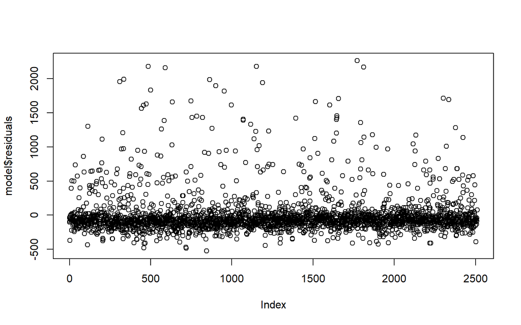

```r
plot(model$residuals)
```

```r
regression_data_clean <- regression_data_clean %>%
  mutate(predicted_value = predict(model, newdata = .))
summary(model)
```

```
##
## Call:
## lm(formula = total_value ~ age_at_trade + regular_goals + regular_assists +
##     regular_hits + regular_atoi + aav + position, data = regression_data_clean)
##
## Residuals:
##     Min      1Q  Median      3Q     Max
## -524.51 -131.37  -70.23    5.46 2261.62
##
## Coefficients:
##                   Estimate Std. Error t value Pr(>|t|)
## (Intercept)      2.761e+02  5.652e+01   4.885 1.10e-06 ***
## age_at_trade    -1.417e+01  1.840e+00  -7.705 1.87e-14 ***
## regular_goals   -7.941e-01  1.898e-01  -4.184 2.96e-05 ***
## regular_assists  7.761e-01  1.386e-01   5.598 2.40e-08 ***
## regular_hits    -1.961e-02  1.842e-02  -1.065  0.28709
## regular_atoi     2.136e-01  3.745e-02   5.705 1.30e-08 ***
## aav              2.401e-05  4.164e-06   5.766 9.12e-09 ***
## positionD       -5.705e+01  3.332e+01  -1.712  0.08701 .
## positionF       -6.336e+00  6.348e+01  -0.100  0.92051
## positionG        8.082e+00  3.303e+01   0.245  0.80673
## positionLD      -4.835e+01  2.075e+01  -2.330  0.01987 *
## positionLW      -1.906e+01  1.864e+01  -1.022  0.30666
## positionRD      -6.533e+01  2.174e+01  -3.006  0.00268 **
## positionRW       4.527e-01  1.888e+01   0.024  0.98087
## positionW       -2.877e+01  2.157e+02  -0.133  0.89391
## ---
## Signif. codes:  0 '***' 0.001 '**' 0.01 '*' 0.05 '.' 0.1 ' ' 1
##
## Residual standard error: 304.3 on 2496 degrees of freedom
##   (8 observations deleted due to missingness)
## Multiple R-squared:  0.09699,    Adjusted R-squared:  0.09193
## F-statistic: 19.15 on 14 and 2496 DF,  p-value: < 2.2e-16
```

## 5.1 Model Fit Visualization

The scatterplot below compares predicted vs. actual trade value. A tight cluster along the red diagonal line would indicate a well-fitting model.

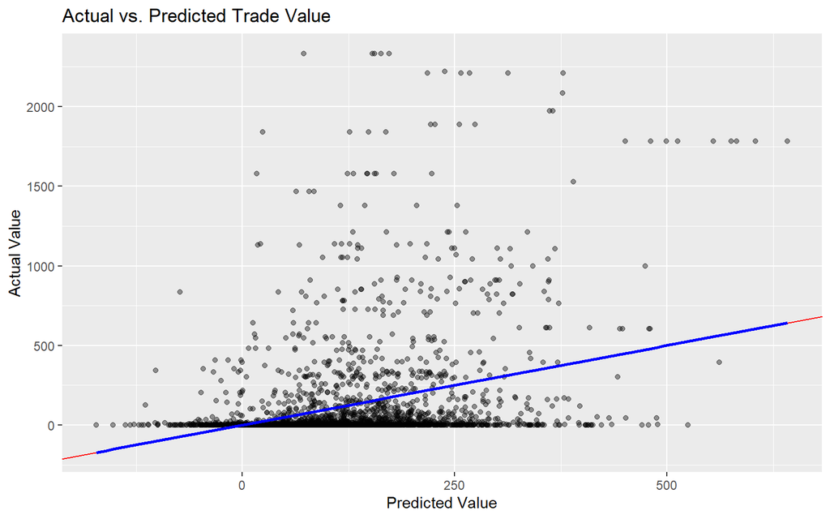

```r
ggplot(regression_data_clean, aes(x = predicted_value, y = total_value)) +
  geom_point(alpha = 0.4) +
  geom_abline(color = "red") +
  geom_smooth(method = "lm", se = FALSE, color = "blue") +
  labs(title = "Actual vs. Predicted Trade Value",
       x = "Predicted Value", y = "Actual Value")
```

## 5.2 Top Prediction Misses

This chart shows the players with the largest prediction residuals (difference between actual and predicted value). Large positive or negative residuals suggest our model over- or under-estimated their worth.

```r
regression_data_clean |>
  mutate(residual = total_value - predicted_value) |>
  arrange(desc(abs(residual))) |>
  select(player_id, total_value, predicted_value, residual) |>
  head(10)
```

```
## # A tibble: 10 × 4
##    player_id total_value predicted_value residual
##        <dbl>       <dbl>           <dbl>    <dbl>
##  1    619152       2334.            72.7    2262.
##  2     61001       2334.           153.     2181.
##  3    168090       2334.           156.     2178.
##  4    620928       2334.           164.     2171.
##  5     78542       2334.           173.     2161.
##  6     55915       2211.           218.     1993.
##  7    118980       2223.           238.     1984.
##  8     55106       2211.           257.     1954.
##  9    181931       2211.           268.     1943.
## 10    127402       2211.           313.     1898.
```

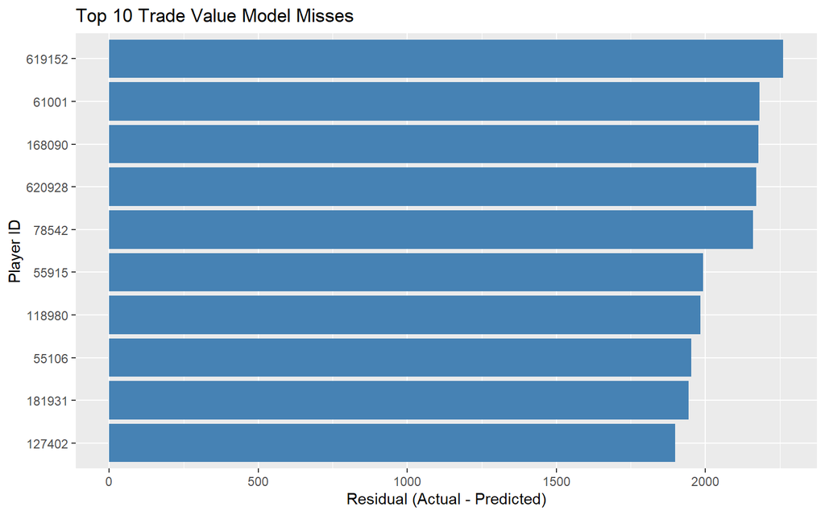

```r
top_misses <- regression_data_clean |>
  mutate(residual = total_value - predicted_value) |>
  slice_max(abs(residual), n = 10)

ggplot(top_misses, aes(x = reorder(as.factor(player_id), residual), y = residual)) +
  geom_bar(stat = "identity", fill = "steelblue") +
  coord_flip() +
  labs(title = "Top 10 Trade Value Model Misses",
       x = "Player ID", y = "Residual (Actual - Predicted)")
```

Outliers may result from team-specific trade strategies, reputational value, or qualitative aspects like leadership or past playoff success — none of which are captured in our numeric model.

# 6 Predicting Value for Current Kings Roster

We now apply our model to the current Kings players. The goal is to estimate what each player might fetch in a trade based on their stats and contract situation.

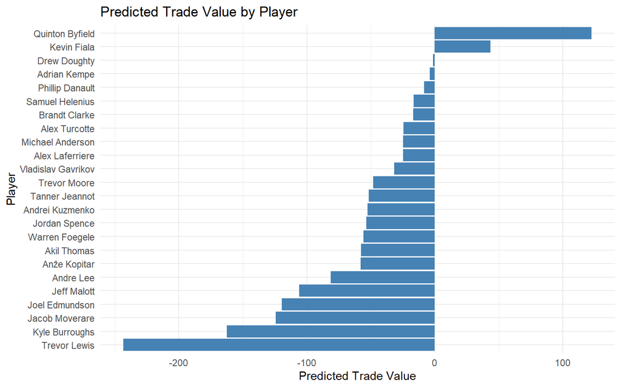

```r
kings_data <- kings_data %>%
  mutate(predicted_value = predict(model, newdata = .)) %>%
  arrange(predicted_value)

ggplot(kings_data, aes(x = reorder(Player, predicted_value), y = predicted_value)) +
  geom_col(fill = "steelblue") +
  coord_flip() +
  labs(
    title = "Predicted Trade Value by Player",
    x = "Player",
    y = "Predicted Trade Value"
  ) +
  theme_minimal()
```

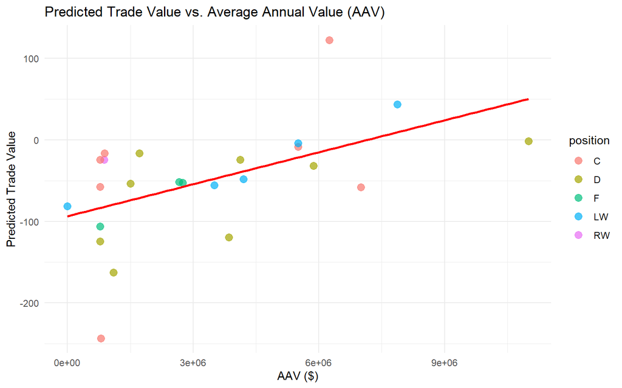

```r
ggplot(kings_data, aes(x = aav, y = predicted_value)) +
  geom_point(aes(color = position), size = 3, alpha = 0.7) +
  geom_smooth(method = "lm", se = FALSE, color = "red") +
  labs(
    title = "Predicted Trade Value vs. Average Annual Value (AAV)",
    x = "AAV ($)",
    y = "Predicted Trade Value"
  ) +
  theme_minimal()
```

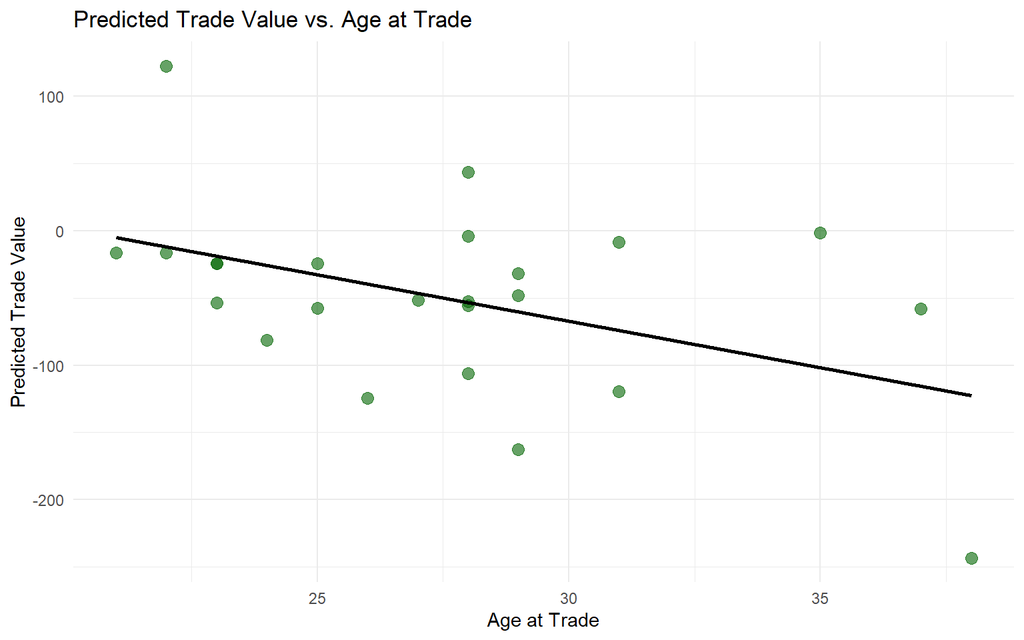

```r
ggplot(kings_data, aes(x = age_at_trade, y = predicted_value)) +
  geom_point(color = "darkgreen", size = 3, alpha = 0.6) +
  geom_smooth(method = "lm", se = FALSE, color = "black") +
  labs(
    title = "Predicted Trade Value vs. Age at Trade",
    x = "Age at Trade",
    y = "Predicted Trade Value"
  ) +
  theme_minimal()
```

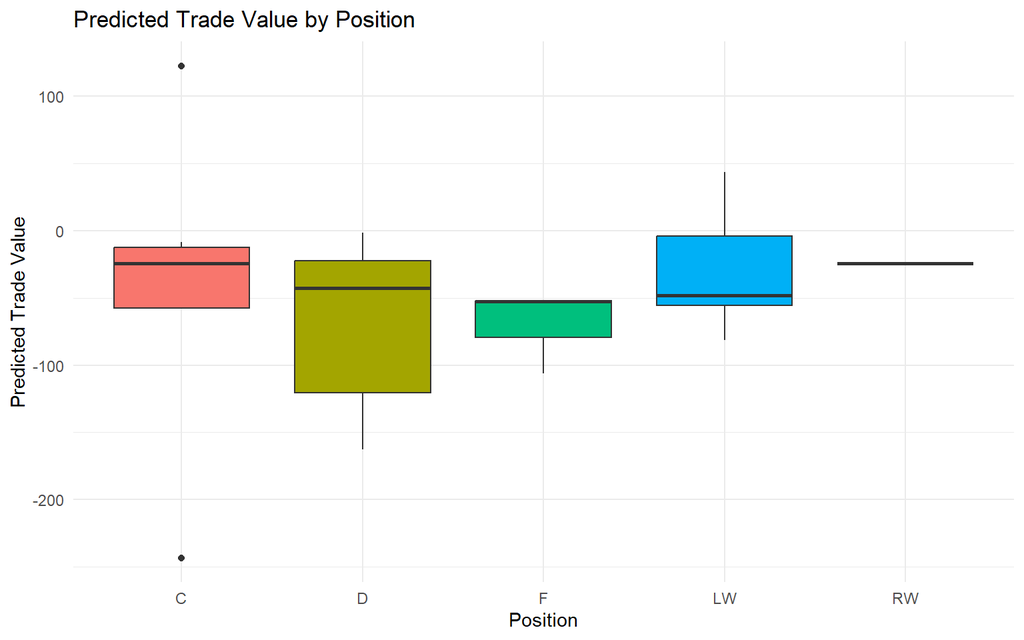

```r
ggplot(kings_data, aes(x = position, y = predicted_value, fill = position)) +
  geom_boxplot() +
  labs(
    title = "Predicted Trade Value by Position",
    x = "Position",
    y = "Predicted Trade Value"
  ) +
  theme_minimal() +
  theme(legend.position = "none")
```

Below is a table of the five current LA Kings players with the highest predicted trade values according to our model.

```r
kings_data %>%
  arrange(desc(predicted_value)) %>%
  select(Player, predicted_value) %>%
  head(5)
```

```
## # A tibble: 5 × 2
##   Player          predicted_value
##   <chr>                     <dbl>
## 1 Quinton Byfield          122.
## 2 Kevin Fiala               43.5
## 3 Drew Doughty              -1.46
## 4 Adrian Kempe              -4.01
## 5 Phillip Danault           -8.35
```

# 7 Discussion

This approach offers the Kings a systematic tool to evaluate trade scenarios and prioritize roster moves.

# 8 Model Limitations

While our model captures many of the quantifiable elements that go into trade valuation, it has several important limitations: It does not account for **leadership**, **locker room presence**, or **injury history**. **Team fit**, **contract context**, and **market timing** are not modeled. Trades involving salary dumps or retention may skew predicted values.

# 9 Conclusion

This project demonstrates how quantitative modeling can support hockey operations. By predicting trade value based on performance and contracts, teams like the LA Kings can make more informed decisions to optimize both short-term competitiveness and long-term sustainability.

*This blog post was created as part of a data analysis project for the LA Kings. Authored by Bryce Markman and Alex White, June 2025.*